# **Previsão da percentagem da despesa total direcionada para alimentação num agregado familiar de Espanha (por mês)**

**GRUPO 4:**

- Gonçalo Mealha 123391
- Jingyu Huang 123432
- Ricardo Valério 112255

# Packages e Importação do Dataset

```r
# packages necessários
set.seed(123)
 #install.packages("corrplot")
library(corrplot) # Matrizes de correlação
 #install.packages("car")
library(car)
 #install.packages("dplyr")
library(dplyr)
 #install.packages("lmtest")
library(lmtest)  # Para testes de hipótese sobre os pressupostos dos resíduos
 #install.packages("tseries")
library(tseries)  # Teste de Jarque-Bera
 #install.packages("caTools") # Separar dataset em teste e treino
library(caTools)
 #install.packages("MASS")
library(MASS)

# Bibliotecas necessárias para a construção dos histogramas e barplots
 #install.packages("ggplot2")
library(ggplot2)
 #install.packages("gridExtra")
library(gridExtra)
 #install.packages("grid")
library(grid)
```

```r
# Importar a base de dados do ficheiro CSV
budget_food_data <- read.csv(
                        file = "BudgetFood_Grupo4.csv",
                        sep = ";",
                        stringsAsFactors = TRUE
                    )[ , -1] # ignorar a 1ª coluna (índice de observações)

# Estrutura do dataframe
str(budget_food_data)
```

```
'data.frame':	2501 obs. of  6 variables:
 $ wfood : num  0.298 0.243 0.653 0.575 0.267 ...
 $ totexp: int  928015 1402566 140676 950352 1226469 643915 498404 511335 982737 437213 ...
 $ age   : int  30 56 44 43 48 56 45 63 44 68 ...
 $ size  : int  6 4 1 6 2 3 5 4 4 3 ...
 $ town  : int  2 2 2 2 2 2 2 2 2 2 ...
 $ sex   : Factor w/ 2 levels "man","woman": 1 1 1 1 1 1 1 1 1 1 ...
```

## Descrição das Variáveis

# Tratamento de dados - Limpezas e Transformações

### Nesta etapa, procedemos a limpeza e a transformação dos dados

```r
# Verificar a existência dos valores nulos
colSums(is.na(budget_food_data))
```

**wfood**

0

**totexp**

0

**age**

0

**size**

0

**town**

0

**sex**

0

```r
# Verificar a existência dos dados duplicados
duplicate <- sum(duplicated(budget_food_data))

# Mostrar os duplicados
budget_food_data[duplicated(budget_food_data) | duplicated(budget_food_data, fromLast = TRUE), ]

# Para remover os duplicados
budget_food_data <- budget_food_data %>% distinct()
```

A data.frame: 12 × 6

|  | wfood <dbl> | totexp <int> | age <int> | size <int> | town <int> | sex <fct> |
| --- | --- | --- | --- | --- | --- | --- |
| 1609 | 0.09017669 | 4384814 | 52 | 4 | 4 | man |
| 1610 | 0.14984846 | 3278272 | 45 | 6 | 4 | man |
| 1611 | 0.19597145 | 904295 | 41 | 2 | 4 | woman |
| 1612 | 0.12740736 | 2051310 | 50 | 4 | 4 | man |
| 1613 | 0.06305279 | 2769362 | 33 | 4 | 4 | man |
| 1614 | 0.21822980 | 1132311 | 45 | 5 | 4 | man |
| 1632 | 0.09017669 | 4384814 | 52 | 4 | 4 | man |
| 1633 | 0.14984846 | 3278272 | 45 | 6 | 4 | man |
| 1634 | 0.19597145 | 904295 | 41 | 2 | 4 | woman |
| 1635 | 0.12740736 | 2051310 | 50 | 4 | 4 | man |
| 1636 | 0.06305279 | 2769362 | 33 | 4 | 4 | man |
| 1637 | 0.21822980 | 1132311 | 45 | 5 | 4 | man |

```r
dim(budget_food_data)  #Foram eliminadas 6 observações
```

1. 2495

2. 6

```r
# Transformar a coluna "sex" para 0 e 1 (woman = 0, man = 1)
budget_food_data$sex <- ifelse(budget_food_data$sex == "woman", 0, 1)

# Visualizar as primeiras linhas do dataframe para verificar a transformação
head(budget_food_data)
```

A data.frame: 6 × 6

|  | wfood <dbl> | totexp <int> | age <int> | size <int> | town <int> | sex <dbl> |
| --- | --- | --- | --- | --- | --- | --- |
| 1 | 0.2978185 | 928015 | 30 | 6 | 2 | 1 |
| 2 | 0.2433597 | 1402566 | 56 | 4 | 2 | 1 |
| 3 | 0.6531605 | 140676 | 44 | 1 | 2 | 1 |
| 4 | 0.5747975 | 950352 | 43 | 6 | 2 | 1 |
| 5 | 0.2668115 | 1226469 | 48 | 2 | 2 | 1 |
| 6 | 0.2880567 | 643915 | 56 | 3 | 2 | 1 |

```r
# Transformar a coluna "totexp" (em Peseta Espanhola) para Euros(€)
# sabendo que 1000 pesetas = 6 euros
budget_food_data$totexp <- budget_food_data$totexp * 6 / 1000

# Visualizar as primeiras linhas do dataframe para verificar a transformação
head(budget_food_data)
```

A data.frame: 6 × 6

|  | wfood <dbl> | totexp <dbl> | age <int> | size <int> | town <int> | sex <dbl> |
| --- | --- | --- | --- | --- | --- | --- |
| 1 | 0.2978185 | 5568.090 | 30 | 6 | 2 | 1 |
| 2 | 0.2433597 | 8415.396 | 56 | 4 | 2 | 1 |
| 3 | 0.6531605 | 844.056 | 44 | 1 | 2 | 1 |
| 4 | 0.5747975 | 5702.112 | 43 | 6 | 2 | 1 |
| 5 | 0.2668115 | 7358.814 | 48 | 2 | 2 | 1 |
| 6 | 0.2880567 | 3863.490 | 56 | 3 | 2 | 1 |

```r
# Casos em que não existe nenhum gasto na alimentação
wfood0 <- which(budget_food_data$wfood == 0)
budget_food_data[wfood0,]

# Para remover
budget_food_data <- budget_food_data[-wfood0, ]
```

A data.frame: 5 × 6

|  | wfood <dbl> | totexp <dbl> | age <int> | size <int> | town <int> | sex <dbl> |
| --- | --- | --- | --- | --- | --- | --- |
| 947 | 0 | 454.560 | 72 | 1 | 2 | 0 |
| 998 | 0 | 798.996 | 78 | 1 | 2 | 1 |
| 1455 | 0 | 3256.440 | 26 | 3 | 2 | 1 |
| 1907 | 0 | 1806.144 | 55 | 2 | 4 | 0 |
| 2012 | 0 | 1355.604 | 49 | 1 | 4 | 1 |

# Análises Descritivas

### Nesta fase, fizemos uma breve análise descrtiva das variáveis através de gráficos e histogramas

```r
summary(budget_food_data)
```

```
     wfood             totexp             age             size
 Min.   :0.01504   Min.   :  121.7   Min.   :18.00   Min.   : 1.000
 1st Qu.:0.26063   1st Qu.: 2638.9   1st Qu.:39.00   1st Qu.: 2.000
 Median :0.36083   Median : 4372.4   Median :51.00   Median : 4.000
 Mean   :0.37822   Mean   : 5167.8   Mean   :51.28   Mean   : 3.706
 3rd Qu.:0.47952   3rd Qu.: 6556.4   3rd Qu.:62.00   3rd Qu.: 5.000
 Max.   :0.95696   Max.   :68385.3   Max.   :97.00   Max.   :17.000
      town            sex
 Min.   :1.000   Min.   :0.0000
 1st Qu.:2.000   1st Qu.:1.0000
 Median :3.000   Median :1.0000
 Mean   :2.755   Mean   :0.8695
 3rd Qu.:4.000   3rd Qu.:1.0000
 Max.   :4.000   Max.   :1.0000
```

### Deteção dos outliers das variáveis numéricas através dos boxplots

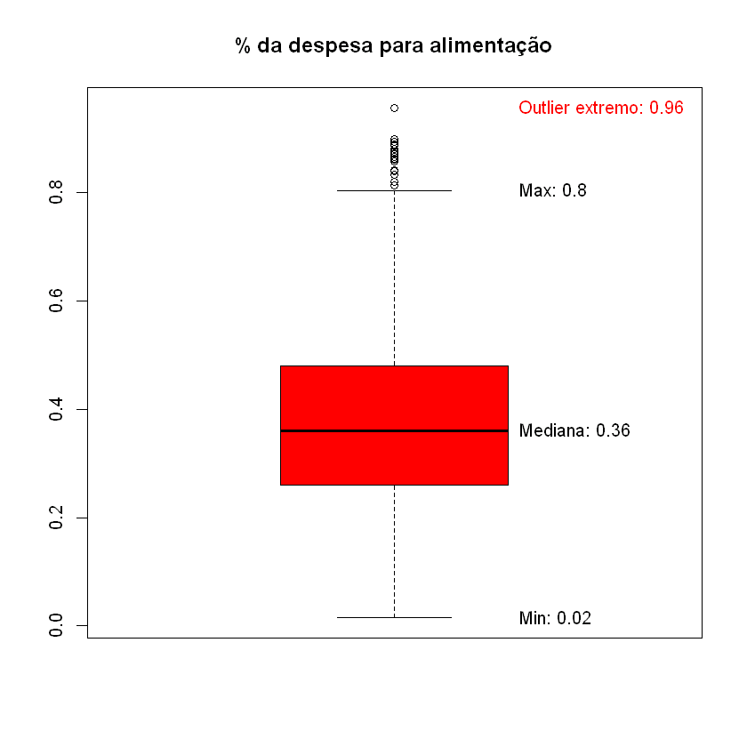

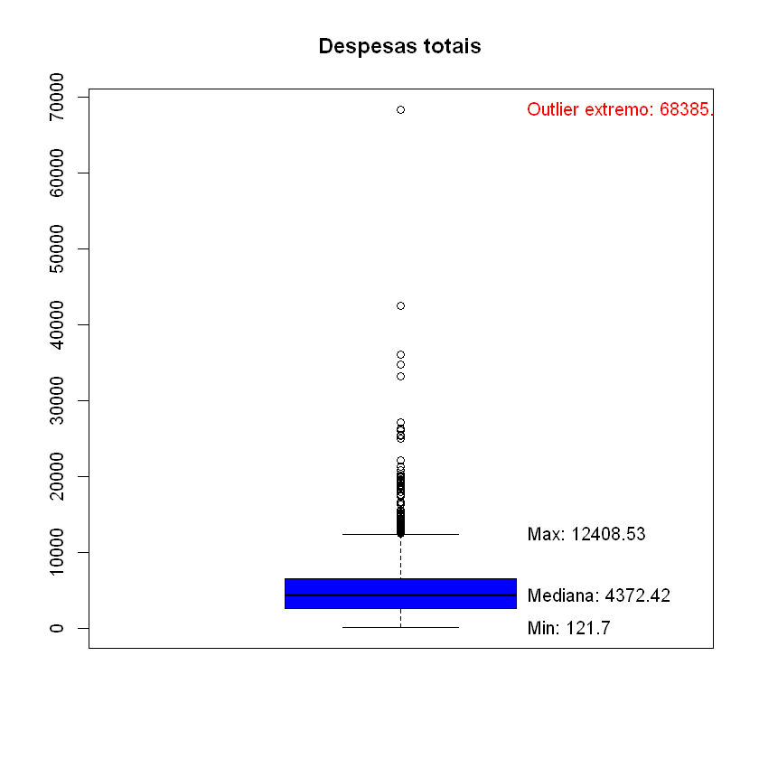

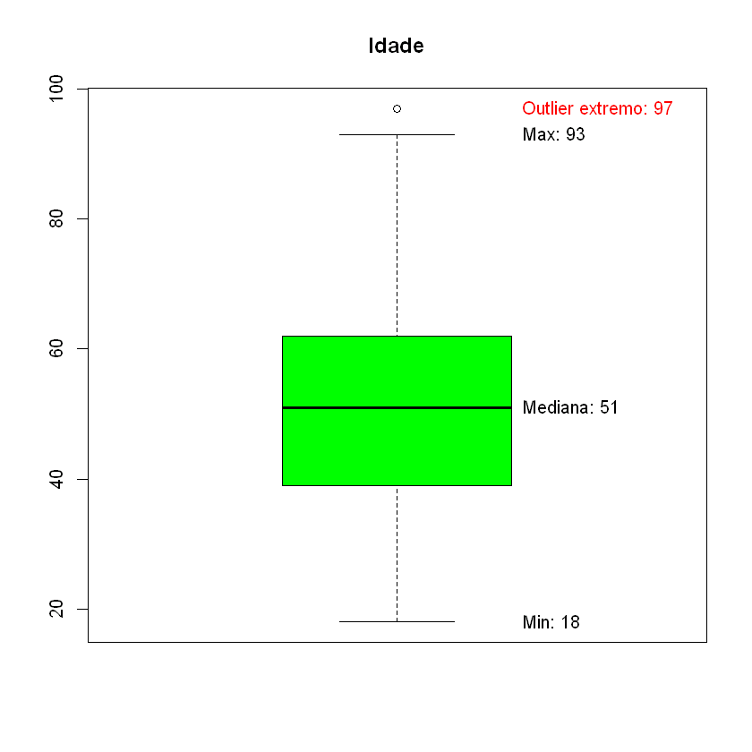

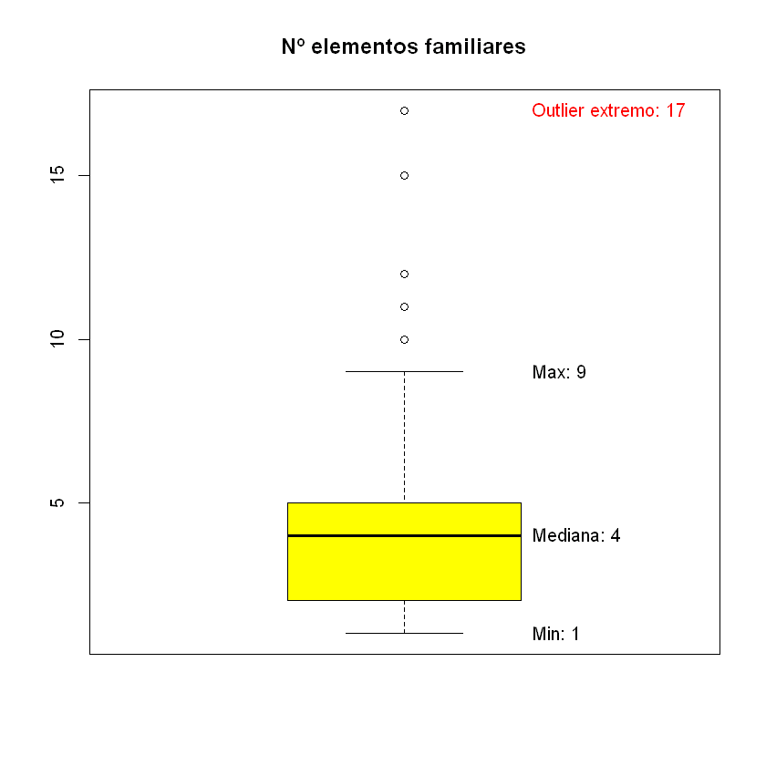

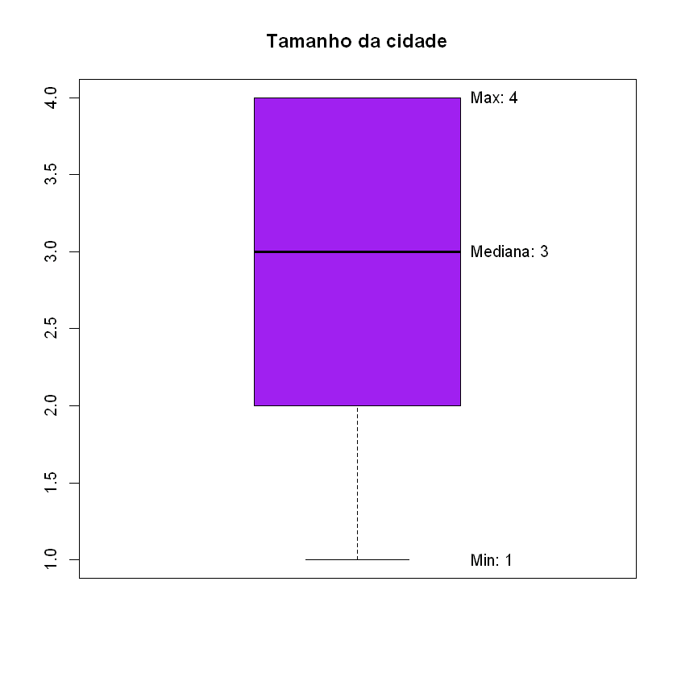

```r
# Outliers das variáveis através do boxplot
variaveis <- list(wfood = budget_food_data$wfood, totexp = budget_food_data$totexp, age = budget_food_data$age, size = budget_food_data$size, town = budget_food_data$town)
titulos <- c("% da despesa para alimentação", "Despesas totais", "Idade", "Nº elementos familiares", "Tamanho da cidade")

# Definir cores para os boxplots
cores <- c("red", "blue", "green", "yellow", "purple")

# Criar os boxplots num ciclo
for (i in 1:length(variaveis)) {
  # Cria o boxplot com cor
  box <- boxplot(variaveis[[i]], main = titulos[i], col = cores[i])

  # Valores estatísticos do boxplot
  min_val <- box$stats[1]  # Mínimo
  q1_val <- box$stats[2]    # Q1
  median_val <- box$stats[3] # Q2
  q3_val <- box$stats[4]    # Q3
  max_val <- box$stats[5]  # Máximo
  outliers <- box$out  # Outliers

  # Identificar o outlier mais extremo (se houver)
  if (length(outliers) > 0) {
    extreme_outlier <- outliers[which.max(abs(outliers - median_val))]  # O mais distante da mediana
    text(1.2, extreme_outlier, labels = paste("Outlier extremo:", round(extreme_outlier, 2)), col = "red", pos = 4)
  }

  # Adicionar os valores no gráfico
  text(1.2, min_val, labels = paste("Min:", round(min_val, 2)), pos = 4, col = "black")
  text(1.2, max_val, labels = paste("Max:", round(max_val, 2)), pos = 4, col = "black")
  text(1.2, median_val, labels = paste("Mediana:", round(median_val, 2)), pos = 4, col = "black")
}
```

**Observações:**

- A variável "town" não possui outliers;
- As restantes variáveis possuem apenas outliers superiores;
- A variável "totexp" apresenta um número elevado de outliers, existem os quais bastante distindos do máximo.

## Histogramas da distribuição das variáveis

Esta secção tem como objetivo analisar e compreender a distribuição dos nossos dados

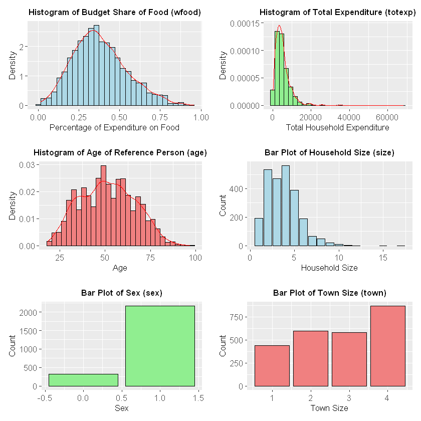

```r
# Definir um tema para melhorar a legibilidade
custom_theme <- theme(
    plot.title = element_text(size = 10, face = "bold", hjust = 0.5),
    axis.title = element_text(size = 10),
    axis.text = element_text(size = 10),
    plot.margin = margin(10, 10, 10, 10)
)

# Histograma da variável wfood
hist_wfood <- ggplot(budget_food_data, aes(x = wfood)) +
    geom_histogram(aes(y = ..density..), bins = 30, fill = "lightblue", color = "black") +
    geom_density(color = "red") + # Adicionar uma curva de densidade em cima do histograma
    ggtitle("Histogram of Budget Share of Food (wfood)") +
    xlab("Percentage of Expenditure on Food") +
    ylab("Density") +
    custom_theme

# Histograma da variável totexp
hist_totexp <- ggplot(budget_food_data, aes(x = totexp)) +
    geom_histogram(aes(y = ..density..), bins = 30, fill = "lightgreen", color = "black") +
    geom_density(color = "red") + # Adicionar uma curva de densidade em cima do histograma
    ggtitle("Histogram of Total Expenditure (totexp)") +
    xlab("Total Household Expenditure") +
    ylab("Density") +
    custom_theme

# Histograma da  variável age
hist_age <- ggplot(budget_food_data, aes(x = age)) +
    geom_histogram(aes(y = ..density..), bins = 30, fill = "lightcoral", color = "black") +
    geom_density(color = "red") + # Adicionar uma curva de densidade em cima do histograma
    ggtitle("Histogram of Age of Reference Person (age)") +
    xlab("Age") +
    ylab("Density") +
    custom_theme

# Barplot da variável size
bar_size <- ggplot(budget_food_data, aes(x = size)) +
    geom_bar(fill = "lightblue", color = "black") +
    ggtitle("Bar Plot of Household Size (size)") +
    xlab("Household Size") +
    ylab("Count") +
    custom_theme

# Barplot da variável sex
bar_age <- ggplot(budget_food_data, aes(x = sex)) +
    geom_bar(fill = "lightgreen", color = "black") +
    ggtitle("Bar Plot of Sex (sex)") +
    xlab("Sex") +
    ylab("Count") +
    custom_theme

# Barplot da variável town
bar_town <- ggplot(budget_food_data, aes(x = town)) +
    geom_bar(fill = "lightcoral", color = "black") +
    ggtitle("Bar Plot of Town Size (town)") +
    xlab("Town Size") +
    ylab("Count") +
    custom_theme

# Organizar gráficos numa matriz
grid.arrange(hist_wfood, hist_totexp,
    hist_age, bar_size,
    bar_age, bar_town,
    ncol = 2, nrow = 3
)
```

```r
# Tabela de frequência absoluta da variável size
table(budget_food_data$size)
```

```
  1   2   3   4   5   6   7   8   9  10  11  12  15  17
193 534 469 562 391 188  66  49  21  11   3   1   1   1
```

### Identificação dos outliers (superiores) das variáveis *wfood*; *totexp*; *age* e *size*

A expressão do cálculo dos outliers superiores é dada por: Outliers = {x ∈ variável ∣ x > Q3 + 1.5 × (Q3−Q1)}

```r
# Para podermos referir variáveis diretamente
attach(budget_food_data)
```

```r
# Outliers da variável "wfood"
out_wfood <- which(wfood>quantile(wfood,prob=0.75)+
                 1.5*(quantile(wfood,prob=0.75)- quantile(wfood,prob=0.25)))

print(paste("Existem", length(out_wfood), "Outliers para a variáviel 'wfood'"))

# Visualizar observações dos outliers em questão
budget_food_data[out_wfood, ]
```

```
[1] "Existem 18 Outliers para a variáviel 'wfood'"
```

A data.frame: 18 × 6

|  | wfood <dbl> | totexp <dbl> | age <int> | size <int> | town <int> | sex <dbl> |
| --- | --- | --- | --- | --- | --- | --- |
| 148 | 0.8588747 | 3617.040 | 78 | 2 | 1 | 1 |
| 150 | 0.8711138 | 397.560 | 68 | 1 | 1 | 0 |
| 155 | 0.8761410 | 652.032 | 75 | 1 | 1 | 0 |
| 209 | 0.8989888 | 4494.036 | 67 | 2 | 2 | 1 |
| 578 | 0.8900860 | 1920.192 | 60 | 2 | 2 | 1 |
| 579 | 0.8333538 | 2542.488 | 35 | 5 | 2 | 1 |
| 605 | 0.9569605 | 606.420 | 97 | 3 | 3 | 0 |
| 685 | 0.8735967 | 1218.576 | 77 | 2 | 2 | 1 |
| 1225 | 0.8607099 | 446.952 | 52 | 2 | 4 | 1 |
| 1336 | 0.8637669 | 4049.148 | 64 | 2 | 1 | 1 |
| 1533 | 0.8659533 | 787.248 | 71 | 1 | 3 | 0 |
| 1768 | 0.8935447 | 1059.036 | 59 | 7 | 2 | 1 |
| 1785 | 0.8404431 | 1370.220 | 67 | 2 | 3 | 1 |
| 1840 | 0.8144171 | 5279.064 | 68 | 2 | 2 | 0 |
| 1853 | 0.8201207 | 775.320 | 70 | 2 | 2 | 1 |
| 2030 | 0.8876501 | 2979.228 | 52 | 4 | 4 | 1 |
| 2172 | 0.8423464 | 3059.454 | 80 | 2 | 1 | 1 |
| 2420 | 0.8811572 | 1916.280 | 84 | 2 | 1 | 1 |

```r
# Outliers da variável "totexp"
out_totexp <- which(totexp>quantile(totexp,prob=0.75)+
                 1.5*(quantile(totexp,prob=0.75)- quantile(totexp,prob=0.25)))

print(paste("Existem", length(out_totexp), "Outliers para a variáviel 'totexp'"))

# Visualizar observações dos outliers em questão
budget_food_data[out_totexp, ]
```

```
[1] "Existem 104 Outliers para a variáviel 'totexp'"
```

A data.frame: 104 × 6

|  | wfood <dbl> | totexp <dbl> | age <int> | size <int> | town <int> | sex <dbl> |
| --- | --- | --- | --- | --- | --- | --- |
| 165 | 0.19357869 | 15203.62 | 39 | 4 | 3 | 1 |
| 170 | 0.37307878 | 13727.61 | 48 | 7 | 2 | 1 |
| 187 | 0.32698148 | 13428.21 | 51 | 6 | 3 | 1 |
| 197 | 0.22126745 | 12769.49 | 27 | 9 | 2 | 1 |
| 230 | 0.20603583 | 22160.26 | 52 | 2 | 2 | 0 |
| 253 | 0.24254123 | 19451.34 | 46 | 6 | 3 | 0 |
| 262 | 0.14491115 | 19932.88 | 52 | 8 | 3 | 1 |
| 264 | 0.13751562 | 17531.27 | 30 | 3 | 3 | 1 |
| 285 | 0.32611576 | 13427.50 | 51 | 7 | 3 | 1 |
| 292 | 0.21130570 | 17609.14 | 39 | 3 | 3 | 1 |
| 303 | 0.14877625 | 19454.88 | 48 | 8 | 4 | 1 |
| 311 | 0.26621841 | 15091.46 | 42 | 4 | 4 | 1 |
| 318 | 0.21593571 | 12570.41 | 60 | 7 | 4 | 1 |
| 320 | 0.24745630 | 14277.62 | 57 | 6 | 4 | 1 |
| 333 | 0.13019256 | 19176.40 | 50 | 8 | 4 | 1 |
| 346 | 0.18581968 | 12898.44 | 49 | 5 | 4 | 1 |
| 364 | 0.24514853 | 14795.11 | 42 | 4 | 4 | 1 |
| 395 | 0.13259323 | 13821.88 | 65 | 2 | 4 | 1 |
| 397 | 0.21216358 | 14267.41 | 59 | 7 | 4 | 1 |
| 398 | 0.04753049 | 36044.06 | 34 | 5 | 4 | 1 |
| 401 | 0.17020395 | 15068.04 | 65 | 3 | 4 | 1 |
| 422 | 0.10033332 | 13032.48 | 38 | 3 | 1 | 1 |
| 494 | 0.17514834 | 19008.76 | 46 | 5 | 3 | 1 |
| 510 | 0.15463602 | 16700.02 | 65 | 6 | 1 | 1 |
| 515 | 0.13614976 | 13144.58 | 61 | 3 | 2 | 1 |
| 525 | 0.23122705 | 15584.68 | 49 | 8 | 3 | 1 |
| 529 | 0.48671714 | 12926.36 | 43 | 5 | 3 | 1 |
| 571 | 0.06620027 | 21307.34 | 43 | 6 | 1 | 1 |
| 609 | 0.25140626 | 12921.49 | 38 | 6 | 3 | 1 |
| 616 | 0.18554892 | 16562.75 | 64 | 9 | 2 | 1 |
| ⋮ | ⋮ | ⋮ | ⋮ | ⋮ | ⋮ | ⋮ |
| 1922 | 0.16607831 | 12613.13 | 68 | 6 | 4 | 1 |
| 1940 | 0.15907759 | 13264.32 | 45 | 4 | 4 | 1 |
| 1948 | 0.18705476 | 13266.96 | 48 | 4 | 4 | 1 |
| 1970 | 0.17976744 | 12787.72 | 36 | 6 | 4 | 1 |
| 1997 | 0.12465494 | 12667.22 | 27 | 4 | 4 | 1 |
| 2002 | 0.11976124 | 15586.81 | 53 | 6 | 4 | 1 |
| 2007 | 0.03566139 | 12878.47 | 67 | 2 | 4 | 1 |
| 2011 | 0.14459614 | 15248.71 | 47 | 7 | 4 | 1 |
| 2016 | 0.06363736 | 17375.45 | 41 | 4 | 4 | 1 |
| 2019 | 0.19102621 | 19970.16 | 50 | 7 | 4 | 1 |
| 2047 | 0.08925939 | 19563.92 | 37 | 3 | 4 | 0 |
| 2093 | 0.14338929 | 18610.43 | 44 | 5 | 2 | 1 |
| 2094 | 0.25896071 | 19933.68 | 46 | 6 | 2 | 1 |
| 2159 | 0.36706705 | 13920.14 | 56 | 5 | 3 | 1 |
| 2165 | 0.36956588 | 19212.23 | 44 | 7 | 2 | 1 |
| 2190 | 0.17623382 | 18027.73 | 59 | 4 | 1 | 1 |
| 2192 | 0.02027410 | 21329.29 | 65 | 2 | 1 | 1 |
| 2212 | 0.07581148 | 25520.04 | 50 | 5 | 3 | 1 |
| 2215 | 0.22758873 | 14029.73 | 56 | 5 | 3 | 1 |
| 2234 | 0.23009087 | 20905.24 | 61 | 3 | 2 | 1 |
| 2255 | 0.11027955 | 14756.97 | 59 | 4 | 1 | 1 |
| 2275 | 0.07125111 | 18378.16 | 48 | 5 | 3 | 1 |
| 2326 | 0.38548279 | 25510.68 | 48 | 10 | 4 | 1 |
| 2360 | 0.01991481 | 68385.28 | 30 | 3 | 4 | 1 |
| 2379 | 0.23808457 | 12775.66 | 56 | 4 | 4 | 1 |
| 2381 | 0.08693240 | 16355.05 | 58 | 3 | 4 | 0 |
| 2463 | 0.15501486 | 19939.92 | 48 | 5 | 2 | 1 |
| 2464 | 0.24102992 | 12702.39 | 57 | 5 | 2 | 1 |
| 2483 | 0.12710192 | 12754.74 | 68 | 3 | 2 | 1 |
| 2484 | 0.27962862 | 14851.96 | 45 | 5 | 2 | 1 |

```r
# Outliers da variável "age"
out_age <- which(age>quantile(age,prob=0.75)+
                 1.5*(quantile(age,prob=0.75)- quantile(age,prob=0.25)))

print(paste("Existem", length(out_age), "Outliers para a variáviel 'age'"))

# Visualizar observações dos outliers em questão
budget_food_data[out_age, ]
```

```
[1] "Existem 1 Outliers para a variáviel 'age'"
```

A data.frame: 1 × 6

|  | wfood <dbl> | totexp <dbl> | age <int> | size <int> | town <int> | sex <dbl> |
| --- | --- | --- | --- | --- | --- | --- |
| 605 | 0.9569605 | 606.42 | 97 | 3 | 3 | 0 |

```r
# Outliers da variável "size"
out_size <- which(size>quantile(size,prob=0.75)+
                 1.5*(quantile(size,prob=0.75)- quantile(size,prob=0.25)))

print(paste("Existem", length(out_size), "Outliers para a variáviel 'size'"))

# Visualizar observações dos outliers em questão
budget_food_data[out_size, ]
```

```
[1] "Existem 17 Outliers para a variáviel 'size'"
```

A data.frame: 17 × 6

|  | wfood <dbl> | totexp <dbl> | age <int> | size <int> | town <int> | sex <dbl> |
| --- | --- | --- | --- | --- | --- | --- |
| 281 | 0.5085926 | 5171.448 | 36 | 10 | 3 | 1 |
| 512 | 0.3938285 | 4966.446 | 44 | 11 | 1 | 1 |
| 624 | 0.6909641 | 4129.812 | 59 | 17 | 2 | 1 |
| 748 | 0.7898063 | 1400.394 | 32 | 10 | 4 | 0 |
| 842 | 0.4035172 | 6661.128 | 37 | 10 | 4 | 1 |
| 887 | 0.1004179 | 13357.056 | 44 | 10 | 4 | 1 |
| 952 | 0.7397707 | 1958.196 | 47 | 10 | 2 | 1 |
| 954 | 0.5114084 | 5095.998 | 47 | 11 | 2 | 1 |
| 1004 | 0.6380957 | 2243.814 | 42 | 10 | 2 | 1 |
| 1111 | 0.5397637 | 6277.992 | 57 | 11 | 1 | 1 |
| 1365 | 0.5452784 | 4384.080 | 44 | 10 | 1 | 1 |
| 1529 | 0.3338047 | 11431.116 | 47 | 10 | 3 | 1 |
| 1590 | 0.2314929 | 26086.152 | 58 | 10 | 4 | 1 |
| 1913 | 0.4236173 | 6515.202 | 47 | 10 | 4 | 1 |
| 2072 | 0.6628213 | 3341.136 | 44 | 15 | 3 | 0 |
| 2080 | 0.7719328 | 4833.996 | 36 | 12 | 3 | 1 |
| 2326 | 0.3854828 | 25510.680 | 48 | 10 | 4 | 1 |

## Correlações

### Nesta fase, foram feitas as matrizes de dispersão e de correlação com a finalidade de perceber que tipo de relação existe entre as variáveis.

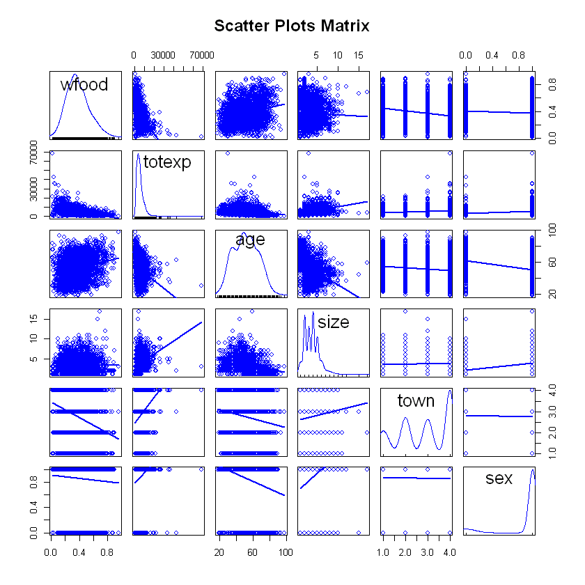

```r
# Matriz de dispersão

scatterplotMatrix(
      budget_food_data,
      smooth = FALSE,
      main = "Scatter Plots Matrix"
)
```

**Observações:**

- Relação mais evidente ocorre entre totexp e wfood, parece uma relação não linear;
- Existe uma leve tendência positiva entre age e wfood;
- Valores dispersos no size que pode surgir uma relação não linear com wfood.

```r
# ====== Matriz de correlação, sex e town com Pearson e Spearman ======

# Criar a matriz completa com todas as variáveis
cor_matrix <- cor(budget_food_data[, c("wfood", "totexp", "age", "size")], method = "pearson")

# Correlação para a dummy (sex)
cor_sex <- sapply(budget_food_data[, c("wfood", "totexp", "age", "size")], function(var) {
  cor(var, budget_food_data$sex, method = "pearson")
})

# Correlação de Spearman para a variável ordinal (town)
cor_town <- sapply(budget_food_data[, c("wfood", "totexp", "age", "size")], function(var) {
  cor(var, budget_food_data$town, method = "spearman")
})

# Adicionar colunas para 'town' e 'sex'
cor_matrix <- cbind(cor_matrix, "town" = cor_town, "sex" = cor_sex)

# Criar uma nova linha para 'town' e 'sex' e adicionar corretamente
new_row_town <- c(cor_town, 1, cor(budget_food_data$sex, budget_food_data$town, method = "spearman"))
new_row_sex <- c(cor_sex, cor(budget_food_data$sex, budget_food_data$town, method = "spearman"), 1)

cor_matrix <- rbind(cor_matrix, "town" = new_row_town, "sex" = new_row_sex)

# Matriz final
cor_matrix
```

A matrix: 6 × 6 of type dbl

|  | wfood | totexp | age | size | town | sex |
| --- | --- | --- | --- | --- | --- | --- |
| wfood | 1.00000000 | -0.5082536 | 0.2573123 | -0.04663193 | -0.26754086 | -0.06302258 |
| totexp | -0.50825357 | 1.0000000 | -0.2623574 | 0.37126596 | 0.27174155 | 0.19201889 |
| age | 0.25731229 | -0.2623574 | 1.0000000 | -0.38470869 | -0.13609020 | -0.27012098 |
| size | -0.04663193 | 0.3712660 | -0.3847087 | 1.00000000 | 0.08750351 | 0.32155099 |
| town | -0.26754086 | 0.2717415 | -0.1360902 | 0.08750351 | 1.00000000 | -0.01993470 |
| sex | -0.06302258 | 0.1920189 | -0.2701210 | 0.32155099 | -0.01993470 | 1.00000000 |

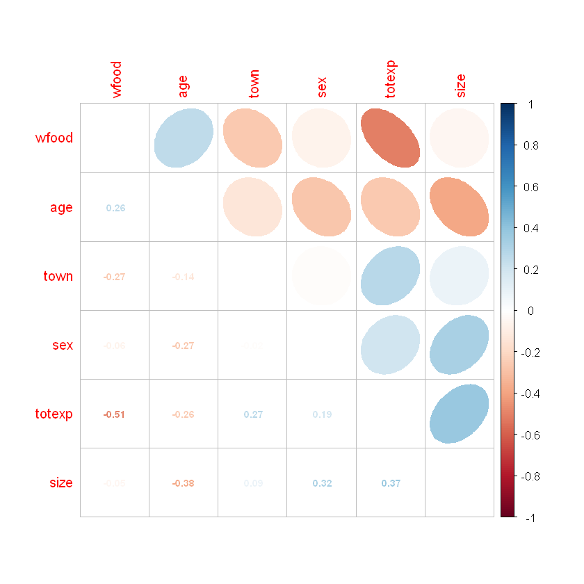

```r
# visualizar as correlações num plot
par(oma = c(2, 2, 2, 2))
corrplot.mixed(
    cor_matrix,
    order = "hclust",
    tl.pos = "lt",
    number.cex = 0.7,
    upper = "ellipse"
)
```

**Observações:**

- A relação entre as variáveis independentes são fracas, o que é importante para a construção do modelo posteriormente.
- A relação mais forte ocorre entre wfood e totexp -> -0.51, uma correlação moderada nagetiva -> À medida que totexp aumenta, a proporção direcionada à alimentação diminui.

# Modelos

### Nesta secção, testámos várias hipóteses para encontrar o modelo ótimo que melhor prevê a nossa variável target - *wfood*

**Modelo1**  
No primeiro modelo, incluiram-se todas as variáveis da base de dados sem transformação nenhuma.

```r
modelo1 <- lm(wfood ~. , data = budget_food_data)
summary(modelo1)

# Para verificar a multicolinearidade entre as variáveis dependentes
vif(modelo1)

# Métrica para averiguar a qualidade de um modelo
AIC(modelo1)
```

```
Call:
lm(formula = wfood ~ ., data = budget_food_data)

Residuals:
     Min       1Q   Median       3Q      Max
-0.47722 -0.08708 -0.01473  0.07892  1.05604

Coefficients:
              Estimate Std. Error t value Pr(>|t|)
(Intercept)  3.573e-01  1.774e-02  20.139   <2e-16 ***
totexp      -2.102e-05  7.463e-07 -28.164   <2e-16 ***
age          2.108e-03  1.994e-04  10.568   <2e-16 ***
size         2.053e-02  1.733e-03  11.846   <2e-16 ***
town        -2.163e-02  2.487e-03  -8.696   <2e-16 ***
sex          5.765e-03  8.561e-03   0.673    0.501
---
Signif. codes:  0 '***' 0.001 '**' 0.01 '*' 0.05 '.' 0.1 ' ' 1

Residual standard error: 0.1336 on 2484 degrees of freedom
Multiple R-squared:  0.3375,	Adjusted R-squared:  0.3362
F-statistic: 253.1 on 5 and 2484 DF,  p-value: < 2.2e-16
```

**totexp**

1.23566664537053

**age**

1.24158525901316

**size**

1.35707711371421

**town**

1.0681419846294

**sex**

1.15973929753808

-2948.77499913199

**Observações:**

- A variável sex tem um p-value de 0.501, pelo que não é significativa a 10%.
- O R^2 é 0.3375.
- O AIC é aproximadamente -2948.77.

### **Verificação dos pressupostos dos resíduos do modelo1**

1.36402267022799e-17

```
	studentized Breusch-Pagan test

data:  modelo1
BP = 174.83, df = 5, p-value < 2.2e-16
```

```
	Breusch-Godfrey test for serial correlation of order up to 1

data:  modelo1
LM test = 30.341, df = 1, p-value = 3.624e-08
```

```
	Jarque Bera Test

data:  modelo1$residuals
X-squared = 536.06, df = 2, p-value < 2.2e-16
```

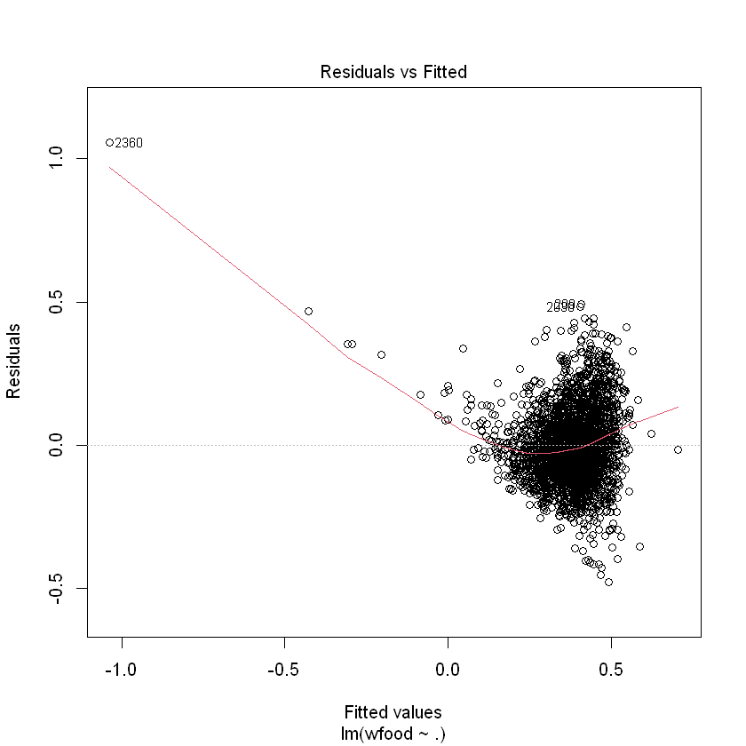

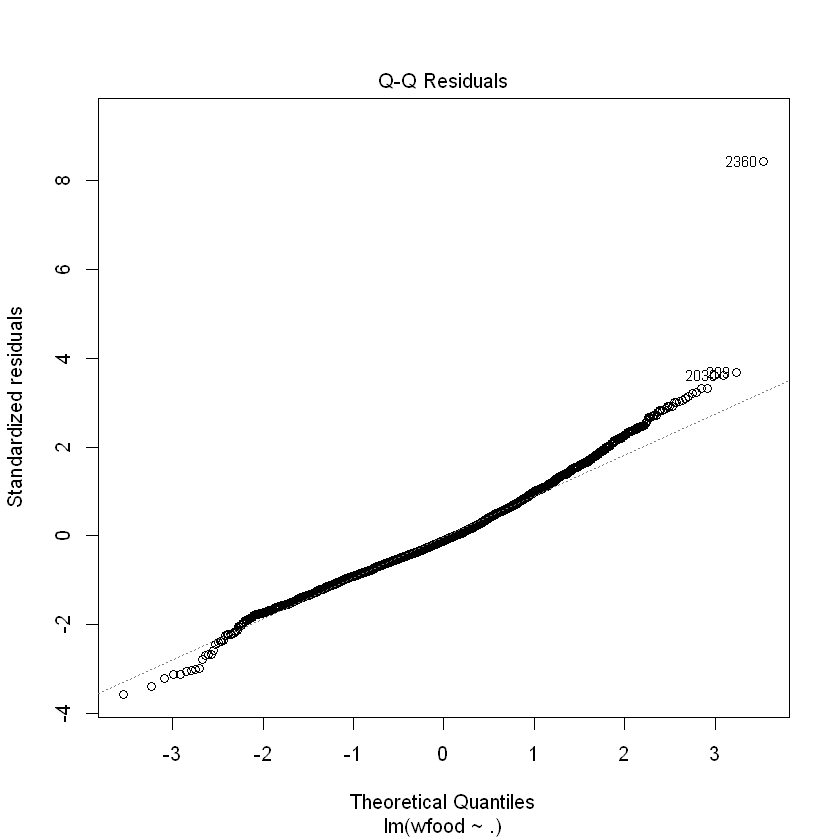

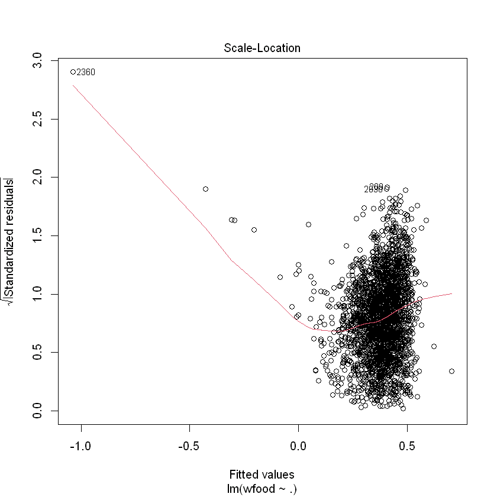

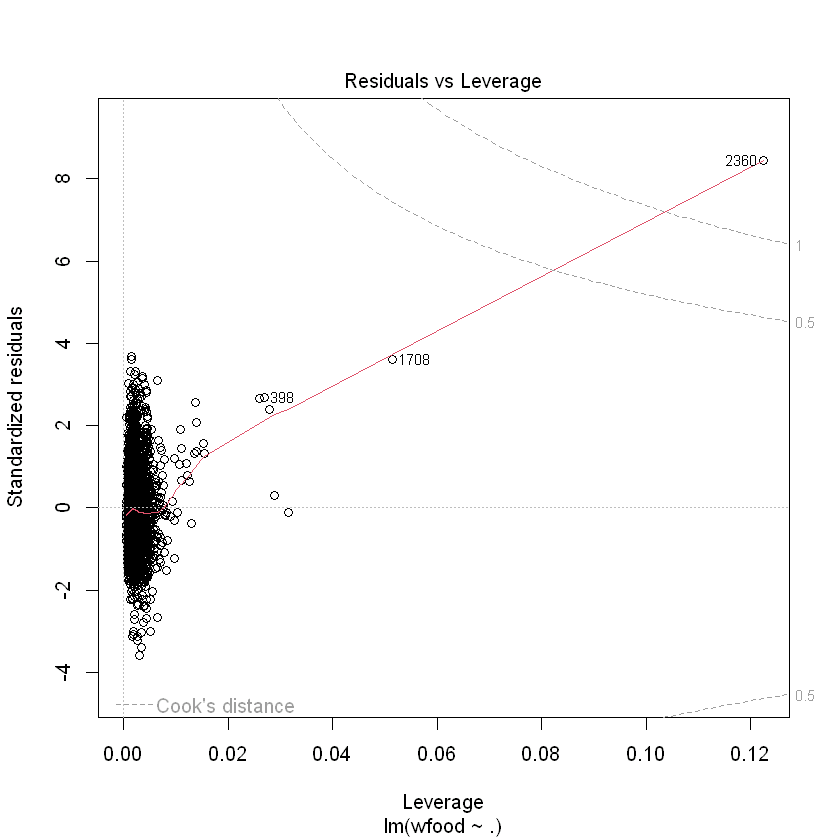

```r
# Verificacão dos pressupostos dos residuos

mean(modelo1$residuals) # média nula
bptest(modelo1) # variância constante
bgtest(modelo1) # independênia entre resíduos
jarque.bera.test(modelo1$residuals) # normalidade

plot(modelo1)
```

**Observações:**

- A média dos reísiduos é estatisticamente nula;
- Com o p-value < 2.2e-16 no teste Breusch-Pagan, reijata-se a H0 de que os resíduos têm variância constante, logo, existe problema de heterocedasticidade -> **Pressuposto de homocedasticidade NÃO verificado**;
- Com o p-value = 3.642e-8 no teste Breusch-Godfrey, reijata-se a H0 de que os resíduos são independentes, logo, existe correlação -> **Pressuposto da ndependência NÃO verificado**;
- Apesar do pressuposto da normalidade dos resíduos não está verificado neste caso, o Teorema do Limite Central garante que, com o aumento do tamanho da amostra, a distribuição dos resíduos tende a se aproximar de uma distribuição normal.

**Modelo2**

Neste modelo, aplicamos a transformação logarítmica à variável *"totexp"* devido à sua grande amplitude e convertimos a variável *"town"* em dummy, adotando town4 como categoria de referência, pois é a mais frequente na base de dados.

```r
# Tabela de frequência absoluta da variável town
table(budget_food_data$town)
```

```
  1   2   3   4
441 599 580 870
```

```r
# Aplicar town4 como categoria de referência
budget_food_data$town <- relevel(as.factor(budget_food_data$town), ref = "4")


modelo2 <- lm(wfood ~ log(totexp) + age + size + sex + as.factor(town) , data = budget_food_data)
summary(modelo2)
AIC(modelo2)
vif(modelo2)
```

```
Call:
lm(formula = wfood ~ log(totexp) + age + size + sex + as.factor(town),
    data = budget_food_data)

Residuals:
     Min       1Q   Median       3Q      Max
-0.66323 -0.07936 -0.01154  0.07364  0.55323

Coefficients:
                  Estimate Std. Error t value Pr(>|t|)
(Intercept)       1.338809   0.038283  34.971  < 2e-16 ***
log(totexp)      -0.140530   0.004268 -32.926  < 2e-16 ***
age               0.001126   0.000196   5.744 1.03e-08 ***
size              0.025226   0.001693  14.897  < 2e-16 ***
sex               0.040710   0.008345   4.879 1.14e-06 ***
as.factor(town)1  0.052920   0.007756   6.823 1.12e-11 ***
as.factor(town)2  0.022281   0.006993   3.186  0.00146 **
as.factor(town)3  0.017993   0.006892   2.611  0.00909 **
---
Signif. codes:  0 '***' 0.001 '**' 0.01 '*' 0.05 '.' 0.1 ' ' 1

Residual standard error: 0.1281 on 2482 degrees of freedom
Multiple R-squared:  0.3917,	Adjusted R-squared:   0.39
F-statistic: 228.4 on 7 and 2482 DF,  p-value: < 2.2e-16
```

-3157.28140153064

A matrix: 5 × 3 of type dbl

|  | GVIF | Df | GVIF^(1/(2*Df)) |
| --- | --- | --- | --- |
| log(totexp) | 1.547588 | 1 | 1.244021 |
| age | 1.305031 | 1 | 1.142380 |
| size | 1.410293 | 1 | 1.187558 |
| sex | 1.199078 | 1 | 1.095024 |
| as.factor(town) | 1.107369 | 3 | 1.017143 |

**Observações:**

- Todas as variáveis são relevantes;
- O R^2 é 0.3917, melhorou em relação ao modelo1;
- O AIC é aproximadamente -3157.281, melhorou em relação ao modelo1

6.05241439417758e-19

```
	studentized Breusch-Pagan test

data:  modelo2
BP = 164.31, df = 7, p-value < 2.2e-16
```

```
	Breusch-Godfrey test for serial correlation of order up to 1

data:  modelo2
LM test = 24.339, df = 1, p-value = 8.079e-07
```

```
	Jarque Bera Test

data:  modelo2$residuals
X-squared = 307.25, df = 2, p-value < 2.2e-16
```

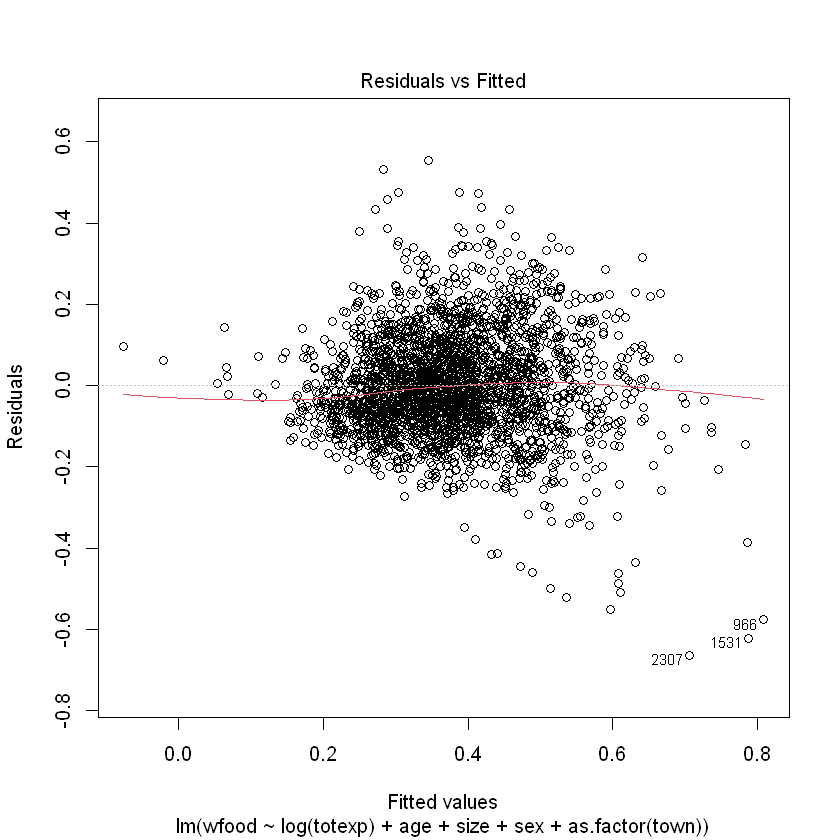

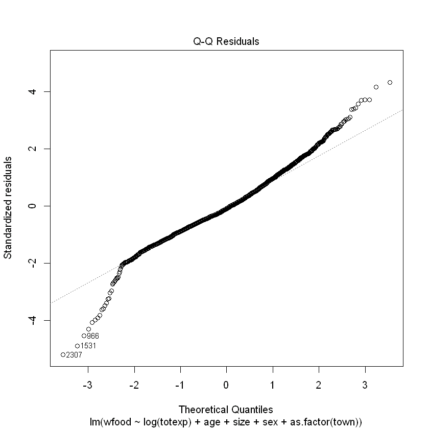

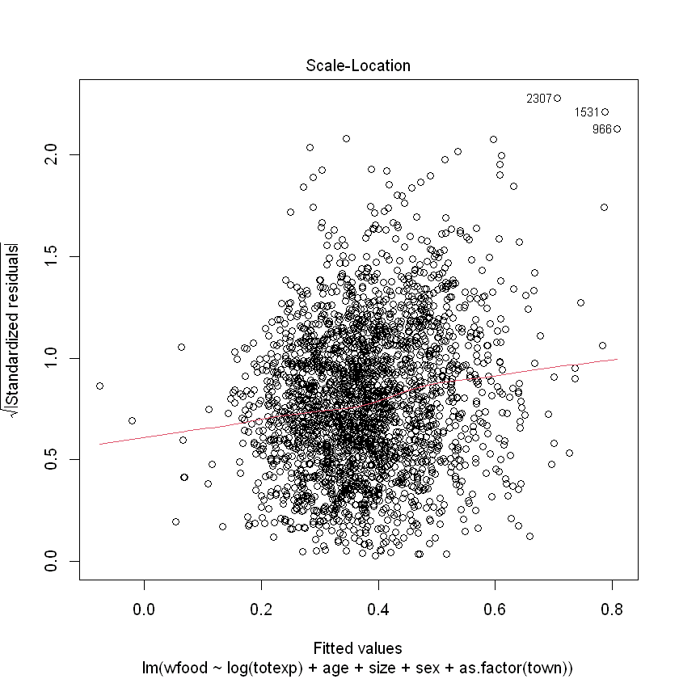

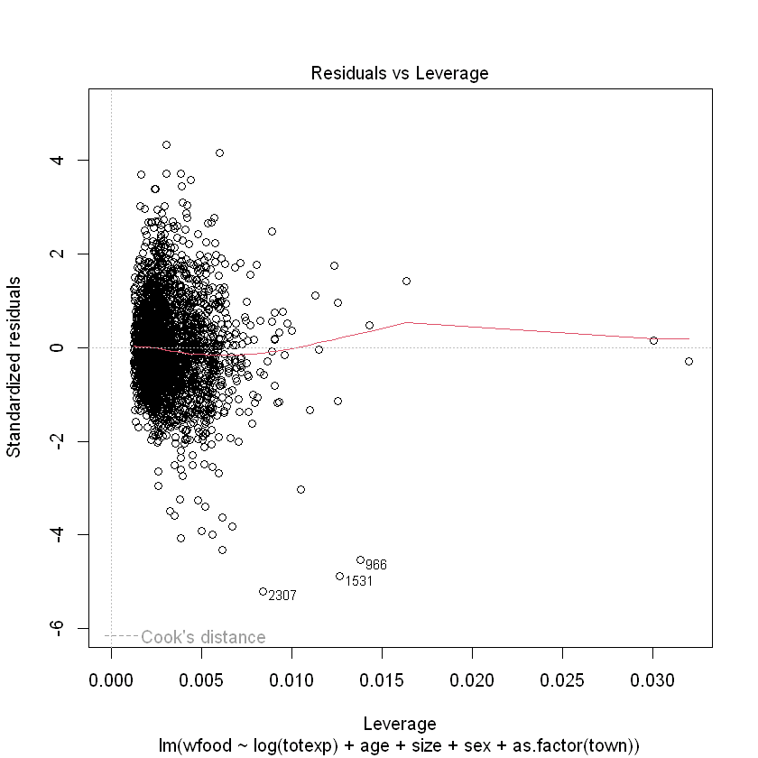

```r
# Verificacão dos pressupostos dos residuos

mean(modelo2$residuals) #média nula
bptest(modelo2) # variância constante
bgtest(modelo2) # independência entre os resíduos
jarque.bera.test(modelo2$residuals) # normalidade

plot(modelo2)
```

**Observações:**

- A média dos reísiduos é estatisticamente nula;
- Com o p-value < 2.2e-16 no teste Breusch-Pagan, rejeita-se a H0 de que os resíduos têm variância constante, logo, existe problema de heterocedasticidade -> **Pressuposto da variância constante NÃO verificado**;
- Com o p-value = 8.079e-07 no teste Breusch-Godfrey, rejeita-se a H0 de que os resíduos são independentes, logo, existe correlação -> **Pressuposto da independência NÃO verificado**;
- Apesar do pressuposto da normalidade dos resíduos não está verificado neste caso, o Teorema do Limite Central garante que, com o aumento do tamanho da amostra, a distribuição dos resíduos tende a se aproximar de uma distribuição normal.

**Modelo3**

Neste modelo, incluimos 2 interações: totexp:size e totexp:as.factor(town). Devido à forte multicolinearidade, retirámos as variáveis as.factor(town) e size.

```r
modelo3 <- lm(wfood ~ log(totexp)  + sex  + age + log(totexp):size
              + log(totexp):as.factor(town) , data = budget_food_data)
summary(modelo3)
AIC(modelo3)
vif(modelo3)
```

```
Call:
lm(formula = wfood ~ log(totexp) + sex + age + log(totexp):size +
    log(totexp):as.factor(town), data = budget_food_data)

Residuals:
     Min       1Q   Median       3Q      Max
-0.66658 -0.08003 -0.01176  0.07426  0.55035

Coefficients:
                               Estimate Std. Error t value Pr(>|t|)
(Intercept)                   1.4331659  0.0386752  37.056  < 2e-16 ***
log(totexp)                  -0.1512046  0.0044615 -33.891  < 2e-16 ***
sex                           0.0444174  0.0083419   5.325 1.10e-07 ***
age                           0.0010341  0.0001956   5.287 1.35e-07 ***
log(totexp):size              0.0028255  0.0001988  14.214  < 2e-16 ***
log(totexp):as.factor(town)1  0.0064044  0.0009468   6.764 1.66e-11 ***
log(totexp):as.factor(town)2  0.0030856  0.0008425   3.662 0.000255 ***
log(totexp):as.factor(town)3  0.0022162  0.0008164   2.715 0.006681 **
---
Signif. codes:  0 '***' 0.001 '**' 0.01 '*' 0.05 '.' 0.1 ' ' 1

Residual standard error: 0.1286 on 2482 degrees of freedom
Multiple R-squared:  0.3873,	Adjusted R-squared:  0.3856
F-statistic: 224.2 on 7 and 2482 DF,  p-value: < 2.2e-16
```

-3139.25711359043

```
there are higher-order terms (interactions) in this model
consider setting type = 'predictor'; see ?vif
```

A matrix: 5 × 3 of type dbl

|  | GVIF | Df | GVIF^(1/(2*Df)) |
| --- | --- | --- | --- |
| log(totexp) | 1.678834 | 1 | 1.295698 |
| sex | 1.189655 | 1 | 1.090713 |
| age | 1.290138 | 1 | 1.135842 |
| log(totexp):size | 1.601916 | 1 | 1.265668 |
| log(totexp):as.factor(town) | 1.061264 | 3 | 1.009959 |

**Observações:**

- Todas as variáveis são relevantes;
- O R^2 é 0.3873, piorou em relação ao modelo2;
- O AIC é aproximadamente -3139.257, também piorou em relação ao modelo2.

-8.8121579526674e-18

```
	studentized Breusch-Pagan test

data:  modelo3
BP = 165.37, df = 7, p-value < 2.2e-16
```

```
	Breusch-Godfrey test for serial correlation of order up to 1

data:  modelo3
LM test = 23.977, df = 1, p-value = 9.747e-07
```

```
	Jarque Bera Test

data:  modelo3$residuals
X-squared = 298.78, df = 2, p-value < 2.2e-16
```

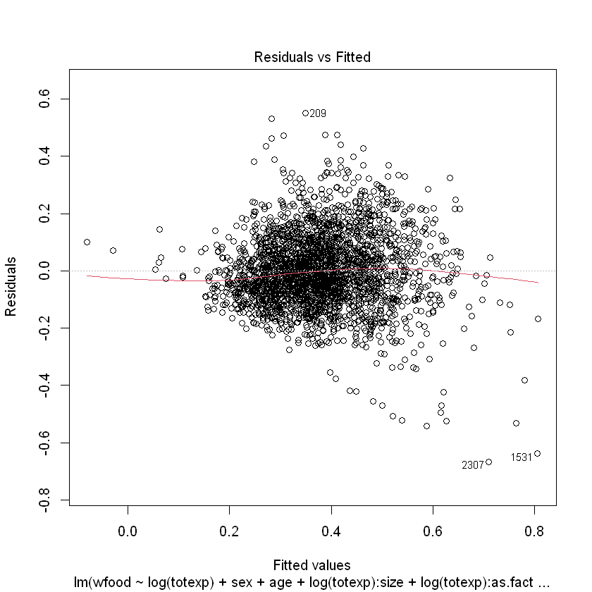

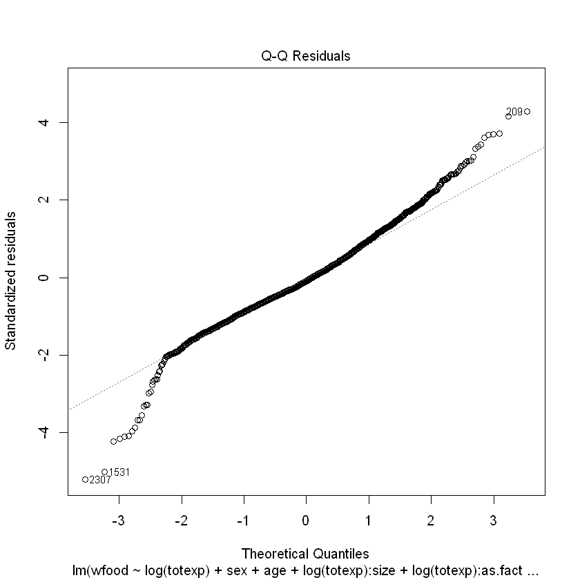

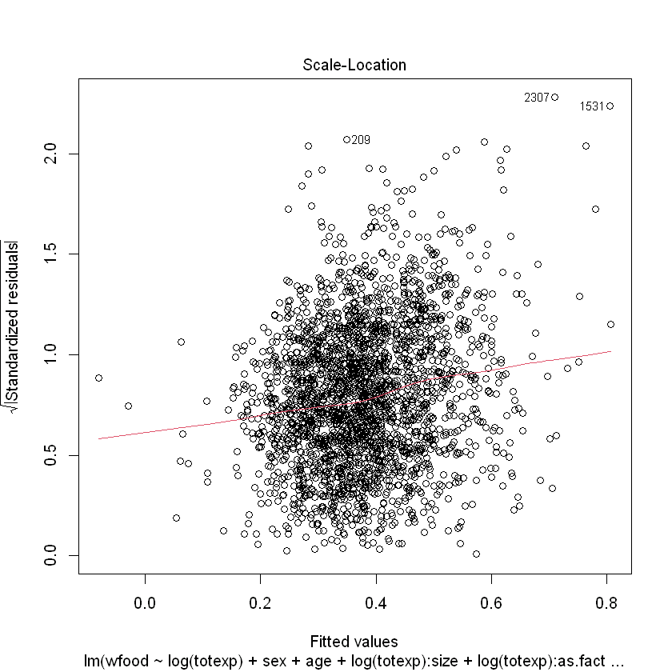

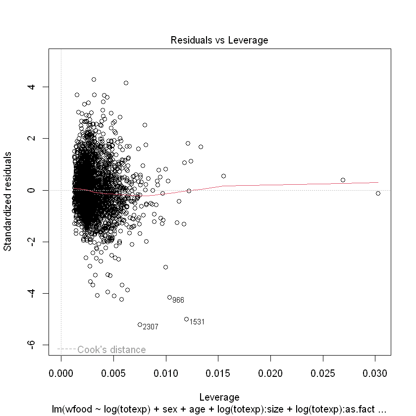

```r
# Verificação dos pressupostos dos resíduos

mean(modelo3$residuals) # média nula
bptest(modelo3) # variância constante
bgtest(modelo3) # independência entre os resíduos
jarque.bera.test(modelo3$residuals) # normalidade

plot(modelo3)
```

**Observações:**

**Modelo4**  
Para lidar com problemas de heterocedasticidade, foi decidido desenvolver um modelo de regrassão ponderado (WSL), onde os pesos foram estimados por um modelo de regressão robusta.

```r
# Modelo robusto que calcula os pesos
modelo4_auxiliar <- rlm(wfood ~ log(totexp)  + sex  + age  + log(totexp):size
                        + log(totexp):as.factor(town) , data = budget_food_data)

# Extração dos pesos
weights <- modelo4_auxiliar$w

# Modelo WLS
modelo4 <- lm(wfood ~ log(totexp)  + sex  + age  + log(totexp):size
              + log(totexp):as.factor(town) , data = budget_food_data, weights = weights )

summary(modelo4)
AIC(modelo4)
vif(modelo4)
```

```
Call:
lm(formula = wfood ~ log(totexp) + sex + age + log(totexp):size +
    log(totexp):as.factor(town), data = budget_food_data, weights = weights)

Weighted Residuals:
     Min       1Q   Median       3Q      Max
-0.32345 -0.07535 -0.00628  0.07800  0.29152

Coefficients:
                               Estimate Std. Error t value Pr(>|t|)
(Intercept)                   1.5390938  0.0339638  45.316  < 2e-16 ***
log(totexp)                  -0.1639672  0.0039169 -41.862  < 2e-16 ***
sex                           0.0447809  0.0073011   6.133 9.98e-10 ***
age                           0.0008700  0.0001693   5.138 3.00e-07 ***
log(totexp):size              0.0030405  0.0001717  17.704  < 2e-16 ***
log(totexp):as.factor(town)1  0.0055246  0.0008233   6.711 2.39e-11 ***
log(totexp):as.factor(town)2  0.0027957  0.0007279   3.841 0.000126 ***
log(totexp):as.factor(town)3  0.0021618  0.0006999   3.089 0.002033 **
---
Signif. codes:  0 '***' 0.001 '**' 0.01 '*' 0.05 '.' 0.1 ' ' 1

Residual standard error: 0.1081 on 2482 degrees of freedom
Multiple R-squared:  0.4793,	Adjusted R-squared:  0.4778
F-statistic: 326.3 on 7 and 2482 DF,  p-value: < 2.2e-16
```

-3821.54339263018

```
there are higher-order terms (interactions) in this model
consider setting type = 'predictor'; see ?vif
```

A matrix: 5 × 3 of type dbl

|  | GVIF | Df | GVIF^(1/(2*Df)) |
| --- | --- | --- | --- |
| log(totexp) | 1.665493 | 1 | 1.290540 |
| sex | 1.180143 | 1 | 1.086344 |
| age | 1.271656 | 1 | 1.127677 |
| log(totexp):size | 1.583288 | 1 | 1.258288 |
| log(totexp):as.factor(town) | 1.062244 | 3 | 1.010115 |

**Observações:**

- Todas as variáveis são relevantes;
- O R^2 é 0.4793, melhorou consideravelmente em relação aos modelos anteriores;
- O AIC é aproximadamente -3821.543, melhorou em relação aos modelos anteriores

```r
# Verificação dos pressupostos dos resíduos

mean(modelo4$residuals) # média nula
bptest(modelo4) # variância constante
bgtest(modelo4) # independência entre resíduos
jarque.bera.test(modelo4$residuals) #normalidade
```

0.00324848452120172

```
	studentized Breusch-Pagan test

data:  modelo4
BP = 47.459, df = 7, p-value = 4.542e-08
```

```
	Breusch-Godfrey test for serial correlation of order up to 1

data:  modelo4
LM test = 23.977, df = 1, p-value = 9.747e-07
```

```
	Jarque Bera Test

data:  modelo4$residuals
X-squared = 394.45, df = 2, p-value < 2.2e-16
```

**Observações:**

- A média dos reísiduos é estatisticamente nula;
- Com o p-value = 4.542e-08 no teste Breusch-Pagan, rejeita-se a H0 de que os resíduos têm variância constante, logo, existe problema de heterocedasticidade -> **Pressuposto da variância constante NÃO verificado**;
- Com o p-value = 9.747e-07 no teste Breusch-Godfrey, rejeita-se a H0 de que os resíduos são independentes, logo, existe correlação -> **Pressuposto da independência NÃO verificado**;
- Apesar do pressuposto da normalidade dos resíduos não está verificado neste caso, o Teorema do Limite Central garante que, com o aumento do tamanho da amostra, a distribuição dos resíduos tende a se aproximar de uma distribuição normal.

**Modelo5**

Neste modelo, a variável dependente passou a ser o valor absoluto da despesa total direcionada para alimentação - wfood*totexp - dada a grande amplitude que totex apresenta, logritmizámos a nossa variável dependente. Utilizámos pesos de 1/sqrt(totexp) com o efeito de reduzir a influência de observações com despesas totais muito elevadas e dão maior peso às de menor despesa.

```r
modelo5<- lm(log(wfood*totexp) ~ log(totexp) + I(totexp^2)  +  sex + age +
               log(totexp):size + log(totexp):as.factor(town),
             data = budget_food_data, weights = 1/sqrt(totexp))

summary(modelo5)
AIC(modelo5)
vif(modelo5)
```

```
Call:
lm(formula = log(wfood * totexp) ~ log(totexp) + I(totexp^2) +
    sex + age + log(totexp):size + log(totexp):as.factor(town),
    data = budget_food_data, weights = 1/sqrt(totexp))

Weighted Residuals:
     Min       1Q   Median       3Q      Max
-0.62257 -0.02437  0.00404  0.03261  0.25232

Coefficients:
                               Estimate Std. Error t value Pr(>|t|)
(Intercept)                   7.492e-01  1.330e-01   5.633 1.97e-08 ***
log(totexp)                   7.116e-01  1.558e-02  45.662  < 2e-16 ***
I(totexp^2)                  -1.293e-09  1.421e-10  -9.100  < 2e-16 ***
sex                           7.919e-02  2.592e-02   3.055  0.00227 **
age                           3.812e-03  6.831e-04   5.581 2.65e-08 ***
log(totexp):size              9.515e-03  7.359e-04  12.930  < 2e-16 ***
log(totexp):as.factor(town)1  2.102e-02  3.265e-03   6.436 1.46e-10 ***
log(totexp):as.factor(town)2  8.505e-03  2.985e-03   2.850  0.00441 **
log(totexp):as.factor(town)3  6.509e-03  3.003e-03   2.168  0.03027 *
---
Signif. codes:  0 '***' 0.001 '**' 0.01 '*' 0.05 '.' 0.1 ' ' 1

Residual standard error: 0.05738 on 2481 degrees of freedom
Multiple R-squared:  0.6847,	Adjusted R-squared:  0.6837
F-statistic: 673.6 on 8 and 2481 DF,  p-value: < 2.2e-16
```

3175.3385218522

```
there are higher-order terms (interactions) in this model
consider setting type = 'predictor'; see ?vif
```

A matrix: 6 × 3 of type dbl

|  | GVIF | Df | GVIF^(1/(2*Df)) |
| --- | --- | --- | --- |
| log(totexp) | 2.215201 | 1 | 1.488355 |
| I(totexp^2) | 1.283793 | 1 | 1.133046 |
| sex | 1.295263 | 1 | 1.138096 |
| age | 1.505720 | 1 | 1.227078 |
| log(totexp):size | 1.798954 | 1 | 1.341251 |
| log(totexp):as.factor(town) | 1.066869 | 3 | 1.010846 |

**Observações:**

- Quase todas as variáveis são relevantes;
- O R^2 é 0.6847, melhorou significativamente em relação aos modelos anteriores;
- O AIC é aproximadamente 3175.339, primeiro modelo com AIC positivo.

-0.00884861781860733

```
	studentized Breusch-Pagan test

data:  modelo5
BP = 5.8783, df = 8, p-value = 0.6609
```

```
	Breusch-Godfrey test for serial correlation of order up to 1

data:  modelo5
LM test = 12.382, df = 1, p-value = 0.0004335
```

```
	Jarque Bera Test

data:  modelo5$residuals
X-squared = 14648, df = 2, p-value < 2.2e-16
```

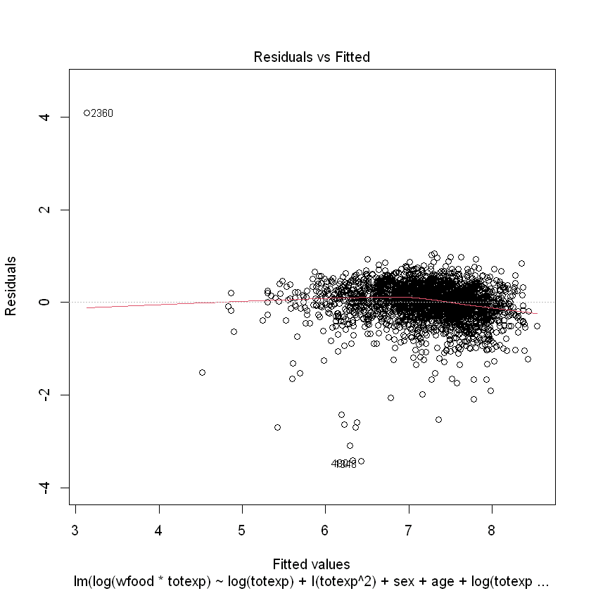

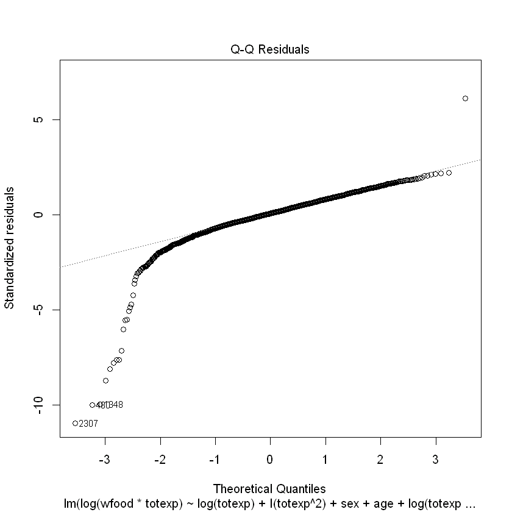

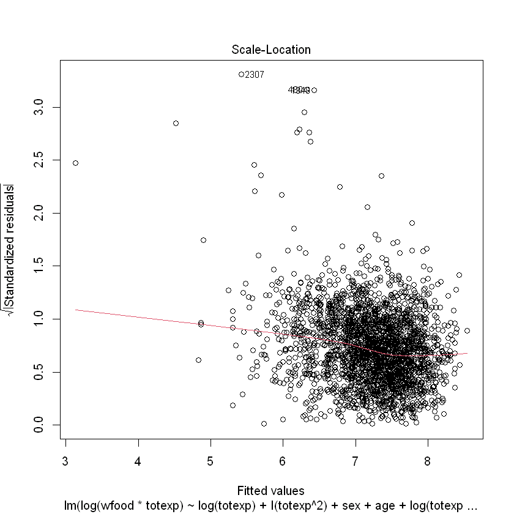

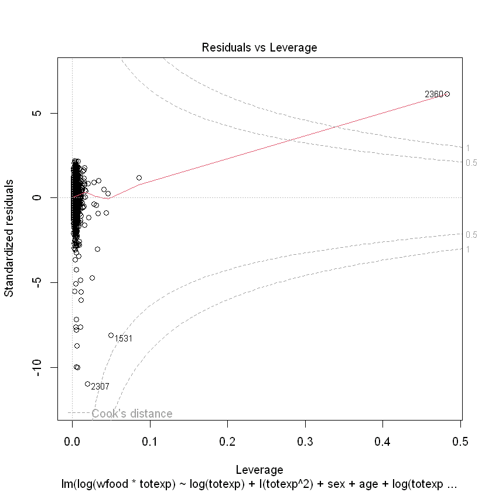

```r
# Verificação dos pressupostos dos resíduos

mean(modelo5$residuals) # média nula
bptest(modelo5) # variância constante
bgtest(modelo5) # independência entre resíduos
jarque.bera.test(modelo5$residuals) # normalidade

plot(modelo5)
```

**Observações:**

- A média dos reísiduos é estatisticamente nula;
- Com o p-value = 0.6609 no teste Breusch-Pagan, não se rejeita a H0 de que os resíduos têm variância constante, logo verificou homocedasticidade -> **Pressuposto da variância constante verificado**;
- Com o p-value = 0.0004335 no teste Breusch-Godfrey, rejeita-se a H0 de que os resíduos são independentes, logo, existe correlação -> **Pressuposto da independência NÃO verificado**;
- Apesar do pressuposto da normalidade dos resíduos não está verificado neste caso, o Teorema do Limite Central garante que, com o aumento do tamanho da amostra, a distribuição dos resíduos tende a se aproximar de uma distribuição normal.

### Passaram a ser verificados três pressupostos.

**Modelo6**

Redefinimos a variável dependente como a despesa alimentar per capita, calculada através da razão (wfood/size).

```r
modelo6 <- lm(((wfood) / size) ~  totexp + age + sex+ as.factor(town) + size:age +(totexp:size)
              + (totexp:as.factor(town)) ,
              data = budget_food_data, weights = 1/sqrt(totexp))
summary(modelo6)
AIC(modelo6)
vif(modelo6)
```

```
Call:
lm(formula = ((wfood)/size) ~ totexp + age + sex + as.factor(town) +
    size:age + (totexp:size) + (totexp:as.factor(town)), data = budget_food_data,
    weights = 1/sqrt(totexp))

Weighted Residuals:
      Min        1Q    Median        3Q       Max
-0.077261 -0.004410 -0.000504  0.003086  0.094738

Coefficients:
                          Estimate Std. Error t value Pr(>|t|)
(Intercept)              2.040e-01  1.033e-02  19.742  < 2e-16 ***
totexp                  -3.009e-05  1.540e-06 -19.537  < 2e-16 ***
age                      4.189e-03  1.354e-04  30.942  < 2e-16 ***
sex                     -5.944e-02  5.333e-03 -11.145  < 2e-16 ***
as.factor(town)1         4.144e-02  8.344e-03   4.966 7.28e-07 ***
as.factor(town)2         3.118e-03  7.727e-03   0.404   0.6866
as.factor(town)3        -4.995e-03  8.267e-03  -0.604   0.5458
age:size                -1.034e-03  3.285e-05 -31.483  < 2e-16 ***
totexp:size              4.876e-06  2.745e-07  17.765  < 2e-16 ***
totexp:as.factor(town)1 -4.582e-06  1.855e-06  -2.469   0.0136 *
totexp:as.factor(town)2  9.430e-07  1.580e-06   0.597   0.5507
totexp:as.factor(town)3  1.722e-06  1.443e-06   1.193   0.2329
---
Signif. codes:  0 '***' 0.001 '**' 0.01 '*' 0.05 '.' 0.1 ' ' 1

Residual standard error: 0.01153 on 2478 degrees of freedom
Multiple R-squared:  0.649,	Adjusted R-squared:  0.6474
F-statistic: 416.5 on 11 and 2478 DF,  p-value: < 2.2e-16
```

-4814.68200247368

```
there are higher-order terms (interactions) in this model
consider setting type = 'predictor'; see ?vif
```

A matrix: 7 × 3 of type dbl

|  | GVIF | Df | GVIF^(1/(2*Df)) |
| --- | --- | --- | --- |
| totexp | 7.674393 | 1 | 2.770269 |
| age | 1.465690 | 1 | 1.210657 |
| sex | 1.359196 | 1 | 1.165845 |
| as.factor(town) | 19.787845 | 3 | 1.644623 |
| age:size | 2.400454 | 1 | 1.549340 |
| totexp:size | 8.177348 | 1 | 2.859606 |
| totexp:as.factor(town) | 24.930797 | 3 | 1.709186 |

**Observações:**

-0.00176987046039865

```
	studentized Breusch-Pagan test

data:  modelo6
BP = 11.556, df = 11, p-value = 0.3979
```

```
	Breusch-Godfrey test for serial correlation of order up to 1

data:  modelo6
LM test = 3.0672, df = 1, p-value = 0.07989
```

```
	Jarque Bera Test

data:  modelo6$residuals
X-squared = 20704, df = 2, p-value < 2.2e-16
```

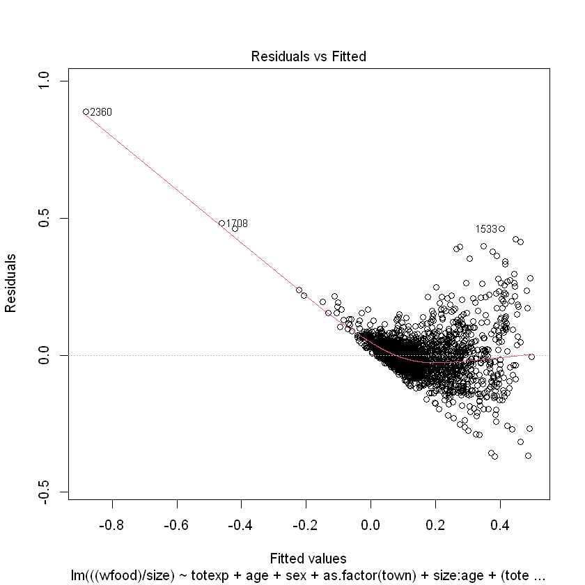

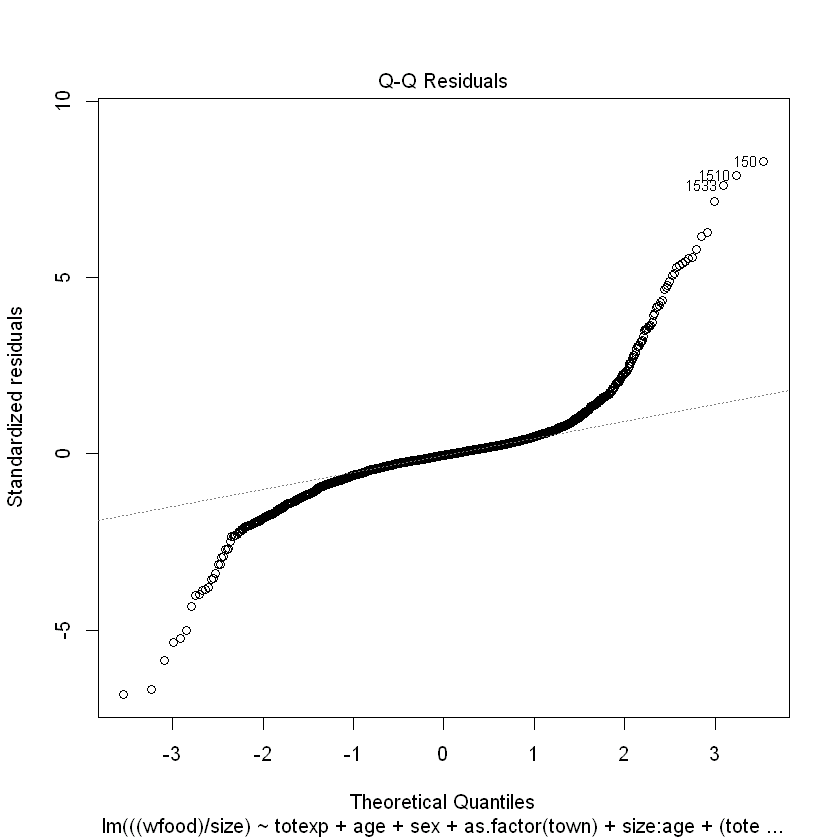

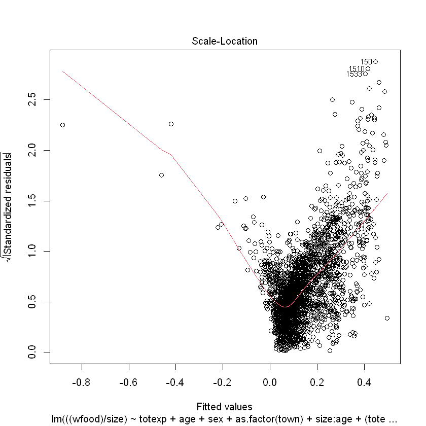

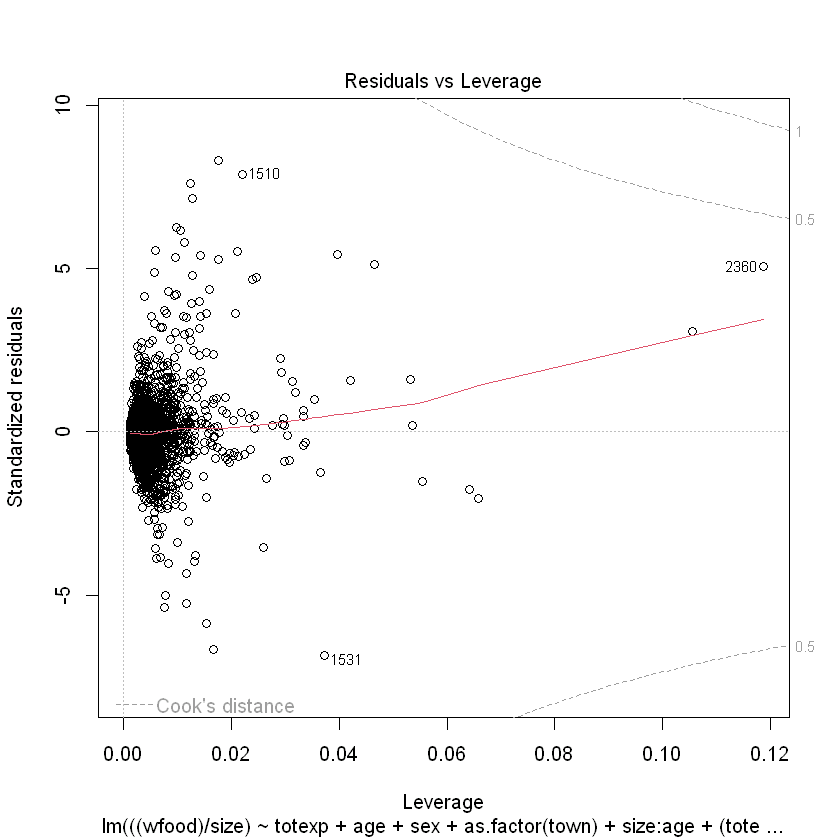

```r
# Verificação dos pressupostos dos resíduos
mean(modelo6$residuals) # média nula
bptest(modelo6) # variância constante
bgtest(modelo6) # independência entre resíduos
jarque.bera.test(modelo6$residuals) # normalidade

plot(modelo6)
```

**Observações:**

- A média dos reísiduos é estatisticamente nula;
- Com o p-value = 0.3979 no teste Breusch-Pagan, não se rejeita a H0 de que os resíduos têm variância constante, logo verificou homocedasticidade -> **Pressuposto da variância constante verificado**;
- Com o p-value = 0.07989 no teste Breusch-Godfrey, não se rejeita a H0 de que os resíduos são independentes, logo **Pressuposto da independência verificado**;
- Apesar do pressuposto da normalidade dos resíduos não está verificado neste caso, o Teorema do Limite Central garante que, com o aumento do tamanho da amostra, a distribuição dos resíduos tende a se aproximar de uma distribuição normal.

### Único modelo que se verificou os três pressupostos

## Resumo dos modelos numa tabela

```r
# Lista de modelos
modelos <- list(modelo1, modelo2, modelo3, modelo4, modelo5, modelo6)
nomes <- c("Modelo 1", "Modelo 2", "Modelo 3", "Modelo 4", "Modelo 5", "Modelo 6")

# Criar a tabela de resultados
resultados <- data.frame(
  Modelo = nomes,
  R2 = sapply(modelos, function(m) round(summary(m)$r.squared, 4)),  # Arredondar R2 para 3 casas decimais
  AIC = sapply(modelos, AIC),
  Média_Nula = sapply(modelos, function(m) ifelse(abs(mean(residuals(m))) < 1e-2, "SIM", "NÃO")),
  # Testes de pressupostos: SIM se p-valor > 0.05, NÃO se p-valor < 0.05
  Homocedasticidade = sapply(modelos, function(m) ifelse(bptest(m)$p.value > 0.05, "SIM", "NÃO")),
  Independência = sapply(modelos, function(m) ifelse(bgtest(m)$p.value > 0.05, "SIM", "NÃO")),
  Normalidade = "SIM" )# Sempre "SIM", com o TLC a normalidade é sempre verificada

resultados
```

A data.frame: 6 × 7

| Modelo <chr> | R2 <dbl> | AIC <dbl> | Média_Nula <chr> | Homocedasticidade <chr> | Independência <chr> | Normalidade <chr> |
| --- | --- | --- | --- | --- | --- | --- |
| Modelo 1 | 0.3375 | -2948.775 | SIM | NÃO | NÃO | SIM |
| Modelo 2 | 0.3917 | -3157.281 | SIM | NÃO | NÃO | SIM |
| Modelo 3 | 0.3873 | -3139.257 | SIM | NÃO | NÃO | SIM |
| Modelo 4 | 0.4793 | -3821.543 | SIM | NÃO | NÃO | SIM |
| Modelo 5 | 0.6847 | 3175.339 | SIM | SIM | NÃO | SIM |
| Modelo 6 | 0.6490 | -4814.682 | SIM | SIM | SIM | SIM |

### Previsão dos modelos no conjunto de teste

```r
set.seed(123)

# Dividir a base de dados em treino(80%) e teste(20%)
index = sample.split(budget_food_data, SplitRatio = 0.8)
train = budget_food_data[index,] # Conjunto de treino
test = budget_food_data[!index,] # Conjunto de teste
```

```r
# Modelos aplicados no conjunto de treino

train1 <- lm(wfood ~. , data = train)

train2 <- lm(wfood ~ log(totexp) + age + size + sex + as.factor(town) , data = train)

train3 <- lm(wfood ~ log(totexp)  + sex  + age + log(totexp):size
              + log(totexp):as.factor(town) , data = train)

# Modelo robusto que calcula os pesos
train4_auxiliar <- rlm(wfood ~ log(totexp)  + sex  + age  + log(totexp):size
                        + log(totexp):as.factor(town) , data = train)

# Extração dos pesos
weights <- train4_auxiliar$w

# Modelo WLS
train4 <- lm(wfood ~ log(totexp)  + sex  + age  + log(totexp):size
              + log(totexp):as.factor(town) , data = train, weights = weights )

train5<- lm(log(wfood*totexp) ~ log(totexp) + I(totexp^2)  +  sex + age +
               log(totexp):size + log(totexp):as.factor(town),
             data = train, weights = 1/sqrt(totexp))

train6 <- lm(((wfood) / size) ~  totexp + age + sex+ as.factor(town) + size:age +(totexp:size)
              + (totexp:as.factor(town)) ,
              data = train, weights = 1/sqrt(totexp))
```

```r
n_obs <- length(test$wfood) # Número de observações no conjunto de teste
actualn_obs <- test$wfood #  Valores reais dos wfood
```

```r
## ============= modelo1 ===========
pred_wfood1_t = predict(train1, newdata = test)

# Cálculo do MAPE
MAPE1t = (1/n_obs) * sum(abs((actualn_obs - pred_wfood1_t) / actualn_obs)) * 100

# Cálculo do RMSE
RMSE1t = sqrt(sum((pred_wfood1_t - actualn_obs)^2) / n_obs)


## ================ modelo2 ===============
pred_wfood2_t = predict(train2, newdata = test)

# Cálculo do MAPE
MAPE2t = (1/n_obs) * sum(abs((actualn_obs - pred_wfood2_t) / actualn_obs)) * 100

# Cálculo do RMSE
RMSE2t = sqrt(sum((pred_wfood2_t - actualn_obs)^2) / n_obs)


## =============== modelo3 ==============
pred_wfood3_t = predict(train3, newdata = test)

# Cálculo do MAPE
MAPE3t = (1/n_obs) * sum(abs((actualn_obs - pred_wfood3_t) / actualn_obs)) * 100

# Cálculo do RMSE
RMSE3t = sqrt(sum((pred_wfood3_t - actualn_obs)^2) / n_obs)


## ========== modelo4 ============
pred_wfood4_t = predict(train4, newdata = test)

# Cálculo do MAPE
MAPE4t = (1/n_obs) * sum(abs((actualn_obs - pred_wfood4_t) / actualn_obs)) * 100

# Cálculo do RMSE
RMSE4t = sqrt(sum((pred_wfood4_t - actualn_obs)^2) / n_obs)


## =========== modelo5 ============
pred_log_wfood_totexp5_train = predict(train5,newdata = test)
pred_wfood_totexp5_t = exp(pred_log_wfood_totexp5_train)

pred_wfood5_t = pred_wfood_totexp5_t / test$totexp

# Cálculo do MAPE
MAPE5t = (1/n_obs) * sum(abs((actualn_obs - pred_wfood5_t) / actualn_obs)) * 100

# Cálculo do RMSE
RMSE5t = sqrt(sum((pred_wfood5_t - actualn_obs)^2) / n_obs)


## ============ modelo6 ==============
pred_wfood_size6_t = predict(train6,newdata = test)

pred_wfood6_t = pred_wfood_size6_t * test$size

# Cálculo do MAPE
MAPE6t = (1/n_obs) * sum(abs((actualn_obs - pred_wfood6_t) / actualn_obs)) * 100

# Cálculo do RMSE
RMSE6t = sqrt(sum((pred_wfood6_t - actualn_obs)^2) / n_obs)
```

### Representação dos resultados dos modelos no teste

```r
# Listar os modelos
modelos <- c("Modelo 1", "Modelo 2", "Modelo 3", "Modelo 4", "Modelo 5", "Modelo 6")

# MAPE de cada modelo
MAPEt <- c(MAPE1t, MAPE2t, MAPE3t, MAPE4t, MAPE5t, MAPE6t)

# RMSE de cada modelo
RMSEt <- c(RMSE1t, RMSE2t, RMSE3t, RMSE4t, RMSE5t, RMSE6t)

# Tabela de resultados
tab_eval_t <- cbind(modelos,"MAPE Out-Sample(%)" = round(MAPEt,3), "RMSE" = round(RMSEt,3))
tab_eval_t
```

A matrix: 6 × 3 of type chr

| modelos | MAPE Out-Sample(%) | RMSE |
| --- | --- | --- |
| Modelo 1 | 40.119 | 0.132 |
| Modelo 2 | 38.161 | 0.13 |
| Modelo 3 | 38.386 | 0.13 |
| Modelo 4 | 37.571 | 0.13 |
| Modelo 5 | 36.547 | 0.135 |
| Modelo 6 | 54.412 | 0.246 |

## **Previsão do modelo 5 sobre o conjunto de teste (50 observações)**

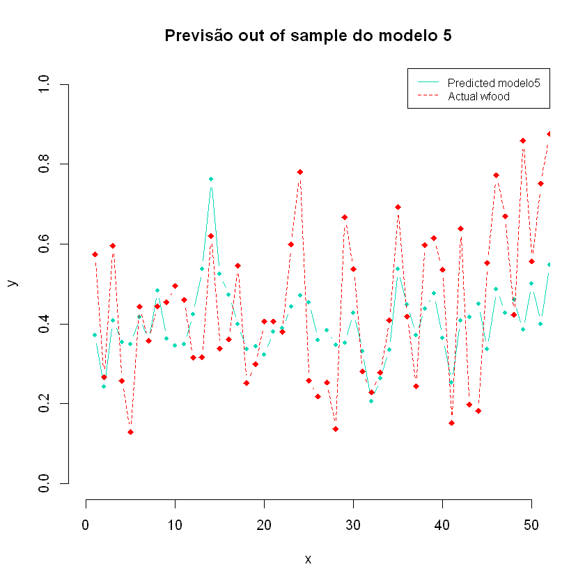

```r
# Previsões do modelo5 para wfood - verde
plot(pred_wfood5_t, type = "b", frame = FALSE, pch = 20, col = "#00d9b5", xlab = "x", ylab = "y",
     xlim=c(0,50), ylim=c(0,1), main="Previsão out of sample do modelo 5")

# Valores reais de wfood - vermelha
lines(actualn_obs, pch = 18, col = "red", type = "b", lty = 2, xlim=c(0,50), ylim=c(0,1))

# Adicionar legendas às linhas do gráfico
legend("topright", legend=c("Predicted modelo5", "Actual wfood"), col=c("#00d9b5", "red"), lty = 1:2, cex=0.8)
```